# DelPrete Final

# Packages

`r`r library(readxl) library(mosaic) library(car) library(multcomp) library(lsmeans)

# Adjusted Data

`r`r DelPrete <- read_excel(.xlsx)

# Changning data into a data frame

DelPrete <- as.data.frame(DelPrete)

## Subsetting

`r`r # Subsetting the data so its just the Terry Collection

DelPreteT <- subset(DelPrete, Collection_number != 1) DelPreteT <- subset(DelPreteT, Collection_number != 2) DelPreteT <- subset(DelPreteT, Collection_number != 3)

`r`r # Subsetting the data so its just the White Terry Collection

DelPreteTW <- subset(DelPrete, Collection_number !=1) DelPreteTW <- subset(DelPreteTW, Collection_number !=2) DelPreteTW <- subset(DelPreteTW, Collection_number !=3)

## AP Inlet

`r`r hist(DelPreteT$Index_AP_inlet, xlab = Inlet, main=of AP Inlet)

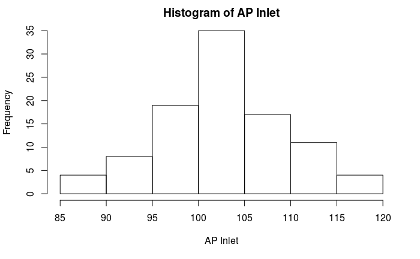

`r`r

plot(DelPreteTW$Index_AP_inlet, DelPreteTW$femur_head_adjusted_1.715, xlab = Inlet, ylab=Head Adjusted, main =Inlet vs. Femur Head)

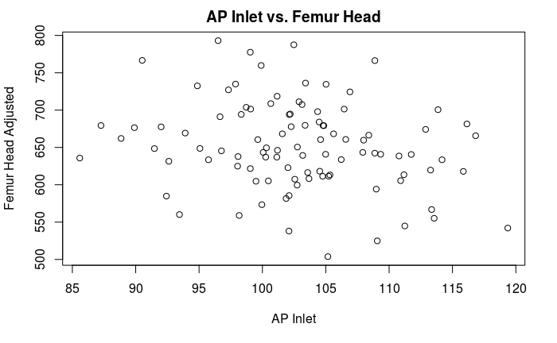

`r`r

cor.test(DelPreteTW$Index_AP_inlet, DelPreteTW$femur_head_adjusted_1.715)

```
    Pearson's product-moment correlation

data:  x and y
t = -2.2645, df = 96, p-value = 0.02579
alternative hypothesis: true correlation is not equal to 0
95 percent confidence interval:
 -0.40548595 -0.02801356
sample estimates:
       cor
-0.2251827
```

## TD Outlet

`r`r hist(DelPreteT$Index_TD_outlet, xlab=Outlet, main=of TD Outlet)

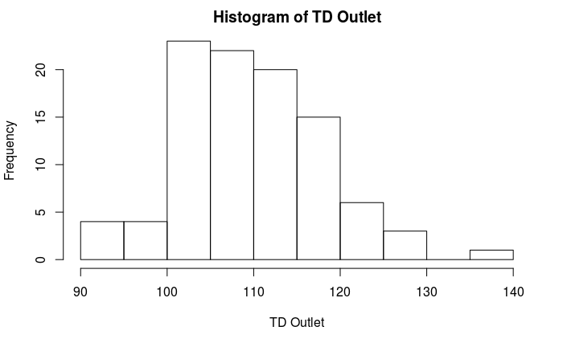

`r`r

plot(DelPreteTW$Index_TD_outlet, DelPreteTW$femur_head_adjusted_1.715, xlab = Outlet, ylab=Head Adjusted, main =Outlet vs. Femur Head)

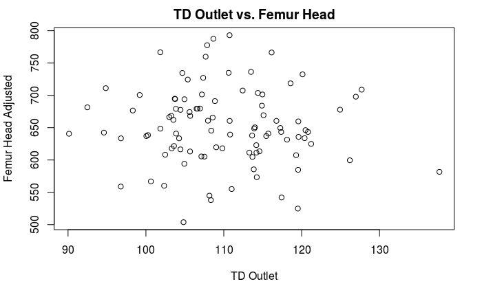

`r`r

cor.test(DelPreteTW$Index_TD_outlet, DelPreteTW$femur_head_adjusted_1.715)

```
    Pearson's product-moment correlation

data:  x and y
t = -0.63516, df = 96, p-value = 0.5268
alternative hypothesis: true correlation is not equal to 0
95 percent confidence interval:
 -0.2597765  0.1354694
sample estimates:
        cor
-0.06469024
```

## Bispinous

`r`r hist(DelPreteT$Index_bispinous, xlab = , main=of Bispinous)

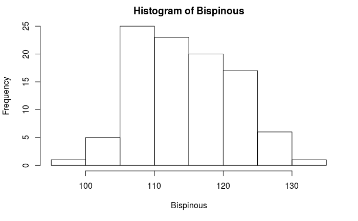

`r`r

plot(DelPreteTW$Index_bispinous, DelPreteTW$femur_head_adjusted_1.715, xlab = , ylab=Head Adjusted, main =vs. Femur Head)

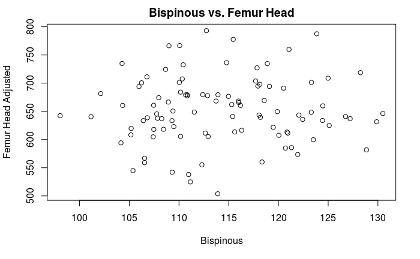

`r`r

cor.test(DelPreteTW$Index_bispinous, DelPreteTW$femur_head_adjusted_1.715)

```
    Pearson's product-moment correlation

data:  x and y
t = 0.38998, df = 96, p-value = 0.6974
alternative hypothesis: true correlation is not equal to 0
95 percent confidence interval:
 -0.1599123  0.2363263
sample estimates:
       cor
0.03977042
```

## Pelvic Breadth

`r`r hist(DelPreteT$Index_pelvic_breadth, xlab = Breadth, main = of Pelvic Breadth)

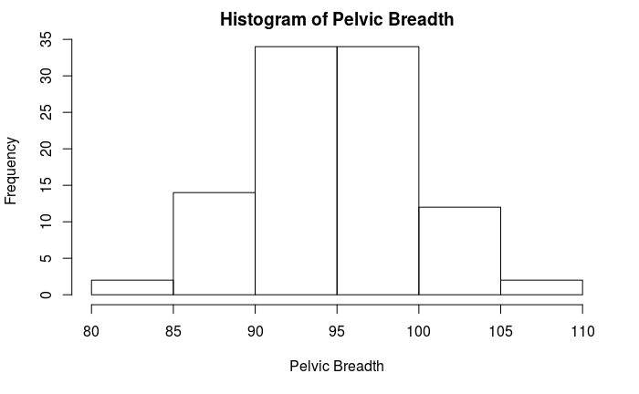

`r`r

plot(DelPreteTW$Index_pelvic_breadth, DelPreteTW$femur_head_adjusted_1.715, xlab = Breadth, ylab=Head Adjusted, main =Breadth vs. Femur Head)

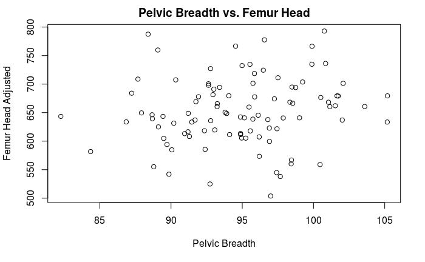

`r`r

cor.test(DelPreteTW$Index_pelvic_breadth, DelPreteTW$femur_head_adjusted_1.715)

```
    Pearson's product-moment correlation

data:  x and y
t = 1.4033, df = 96, p-value = 0.1638
alternative hypothesis: true correlation is not equal to 0
95 percent confidence interval:
 -0.05828654  0.33088652
sample estimates:
      cor
0.1417739
```

## AP Outlet

`r`r hist(DelPreteT$Index_AP_outlet, xlab =Outlet, main =of AP Outlet)

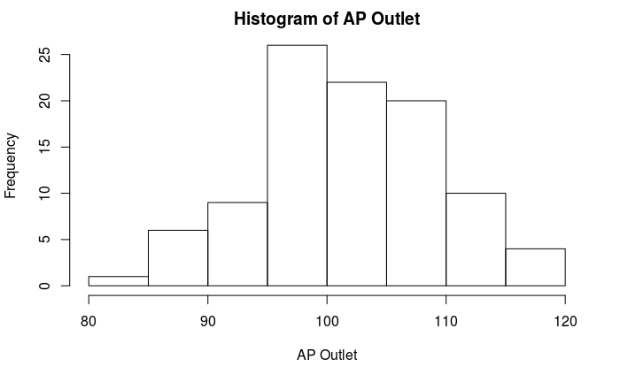

`r`r

plot(DelPreteTW$Index_AP_outlet, DelPreteTW$femur_head_adjusted_1.715, xlab = Outlet, ylab=Head Adjusted, main =Outlet vs. Femur Head)

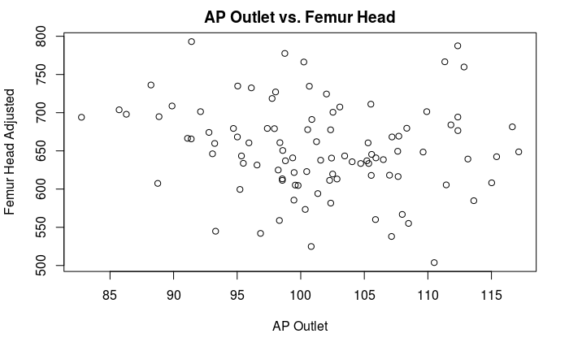

`r`r

cor.test(DelPreteTW$Index_AP_outlet, DelPreteTW$femur_head_adjusted_1.715)

```
    Pearson's product-moment correlation

data:  x and y
t = -1.4643, df = 96, p-value = 0.1464
alternative hypothesis: true correlation is not equal to 0
95 percent confidence interval:
 -0.33636565  0.05213996
sample estimates:
     cor
-0.14781
```

# Raw data

`r`r DelpreteOriginalData <- read_excel(.xlsx, sheet = data)

# Changning data into a data frame

DelpreteOriginalData <- as.data.frame(DelpreteOriginalData)

`r`r # Changing the collection numbers into Locations

DelPrete.orig <- DelpreteOriginalData

TE <- seq(from =4, to=4, length.out=208) HT <- seq(from =3, to=3, length.out=240) C <- seq(from =2, to=2, length.out =155) S <- seq(from =1, to=1, length.out=68)

Collection <- c(TE,C,S,HT) DelPrete.orig$Collection <- Collection DelPrete.orig$Location <- DelPrete.orig$Collection

for (i in 1:length(DelPrete.orig$Collection)) { if (DelPrete.orig$Collection[i] == 1){ DelPrete.orig$Location[i] <- \S\ }else if (DelPrete.orig$Collection[i] == 2){ DelPrete.orig$Location[i] <- \C\ }else if (DelPrete.orig$Collection[i] == 3){ DelPrete.orig$Location[i] <- \HT\ }else if (DelPrete.orig$Collection[i] == 4){ DelPrete.orig$Location[i] <-  
} }

`r`r # Removing a missing data point DelPrete.orig <- subset(DelPrete.orig, `femur head diameter` != )

`r`r # Cleaning up the data # Changing Gender Column so there it’s only M or F

for (i in 1:length(DelPrete.orig$Gender)) { if (DelPrete.orig$Gender[i] == || DelPrete.orig$Gender[i] == \Male\){ DelPrete.orig$Gender[i] <-  
} else if (DelPrete.orig$Gender[i] == \female\ || DelPrete.orig$Gender[i] == ){

```
DelPrete.orig$Gender[i] <- \F\
```

} }

`r`r # Cleaning up the data # Changing Ethnicity Column so there it’s only W or B

for (i in 1:length(DelPrete.orig$Ethnicity)) { if (DelPrete.orig$Ethnicity[i] == || DelPrete.orig$Ethnicity[i] == \white\){ DelPrete.orig$Ethnicity[i] <-  
} else if (DelPrete.orig$Ethnicity[i] == \black\ || DelPrete.orig$Ethnicity[i] == ) { DelPrete.orig$Ethnicity[i] <-  
}

}

`r`r # Combining the Locations and Ethnicities

DelPrete.orig$LocationR <- DelPrete.orig$Location

for (i in 1:length(DelPrete.orig$Location)) { if (DelPrete.orig$Location[i] == && DelPrete.orig$Ethnicity[i] == \W\ ){ DelPrete.orig$LocationR[i] <-  
}else if (DelPrete.orig$Location[i] == \T\ && DelPrete.orig$Ethnicity[i] == ){ DelPrete.orig$LocationR[i] <- \TW\ }else if (DelPrete.orig$Location[i] == && DelPrete.orig$Ethnicity[i] == \B\ ){ DelPrete.orig$LocationR[i] <-  
}else if (DelPrete.orig$Location[i] == \HT\ && DelPrete.orig$Ethnicity[i] == ){ DelPrete.orig$LocationR[i] <- \HTW\ }else if (DelPrete.orig$Location[i] == && DelPrete.orig$Ethnicity[i] == \B\ ){ DelPrete.orig$LocationR[i] <-  
}else if (DelPrete.orig$Location[i] == \C\ && DelPrete.orig$Ethnicity[i] == ){ DelPrete.orig$LocationR[i] <-  
} }

View(DelPrete.orig)

`r`r # Making the predictors into factors for ANCOVA later DelPrete.orig$Gender <- as.factor(DelPrete.orig$Gender) DelPrete.orig$LocationR <- as.factor(DelPrete.orig$LocationR) str(DelPrete.orig)

```
'data.frame':   670 obs. of  15 variables:
 $ Specimen ID                          : chr  \T6RR\ \T17R\ \T22RR\ \T28R\ ...
 $ Gender                               : Factor w/ 2 levels \F\,\M\: 1 1 1 1 1 1 1 1 1 1 ...
 $ Ethnicity                            : chr  \W\ \W\ \W\ \W\ ...
 $ Birthdate                            : num  1881 1883 1885 1879 1865 ...
 $ date of death                        : num  1950 1949 1948 1949 1949 ...
 $ Age                                  : num  69 66 63 70 84 41 60 66 57 80 ...
 $ Pelvic breadth                       : num  285 284 263 266 295 279 262 268 263 282 ...
 $ Anteroposterior diameter of the inlet: num  116 125 115 127 113 ...
 $ Anterioposterior space of outlet adj : num  107 108 112 112 125 ...
 $ Bi-spinous diameter                  : num  93.3 116.1 115.8 115.2 100.9 ...
 $ Transverse diameter of the outlet    : num  120 132 128 135 120 ...
 $ femur head diameter                  : num  44.1 45.6 43.2 43.4 45.6 ...
 $ Collection                           : num  4 4 4 4 4 4 4 4 4 4 ...
 $ Location                             : chr  \T\ \T\ \T\ \T\ ...
 $ LocationR                            : Factor w/ 6 levels \CW\,\HTB\,\HTW\,..: 6 6 6 6 6 6 6 6 6 6 ...
```

## Renaming

`r`r

# Renaming the variables used to simplify the code

DelPrete.orig$Femur.Head.Adj <- DelPrete.orig$`femur head diameter`^1.715 DelPrete.orig$APInlet <- DelPrete.orig$`Anteroposterior diameter of the inlet` DelPrete.orig$PelvicBreadth <- DelPrete.orig$`Pelvic breadth` DelPrete.orig$Bispinous <- DelPrete.orig$`Bi-spinous diameter` DelPrete.orig$TDOutlet <- DelPrete.orig$`Transverse diameter of the outlet` DelPrete.orig$APOutlet <- DelPrete.orig$`Anterioposterior space of outlet adj`

## Histograms

`r`r hist(DelPrete.orig$APInlet, xlab = Inlet, main = Inlet, col = )

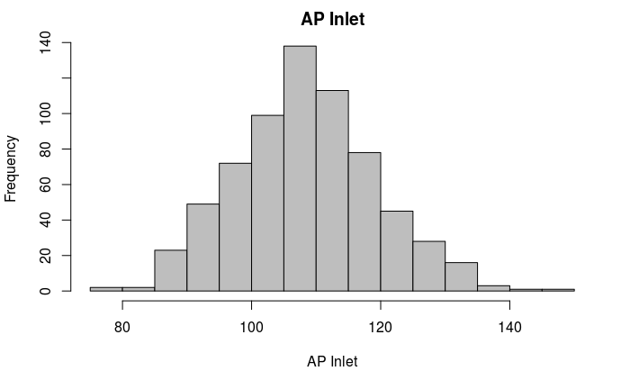

`r`r hist(DelPrete.orig$Bispinous, xlab = , main = , col = )

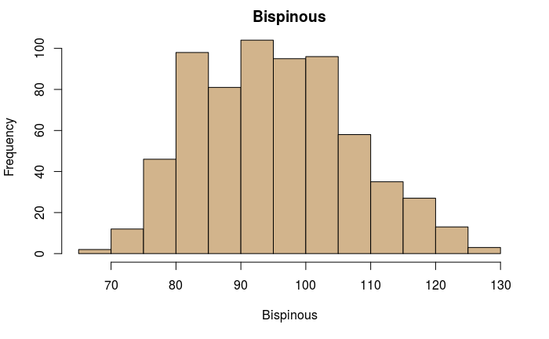

`r`r hist(DelPrete.orig$TDOutlet, xlab = Outlet, main = Outlet, col = )

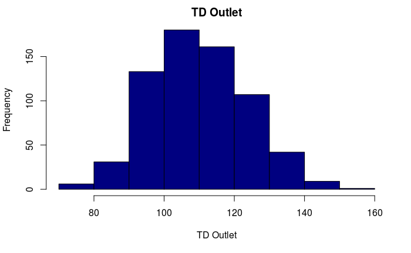

`r`r hist(DelPrete.orig$PelvicBreadth, xlab = Breadth, main = Breadth, col = )

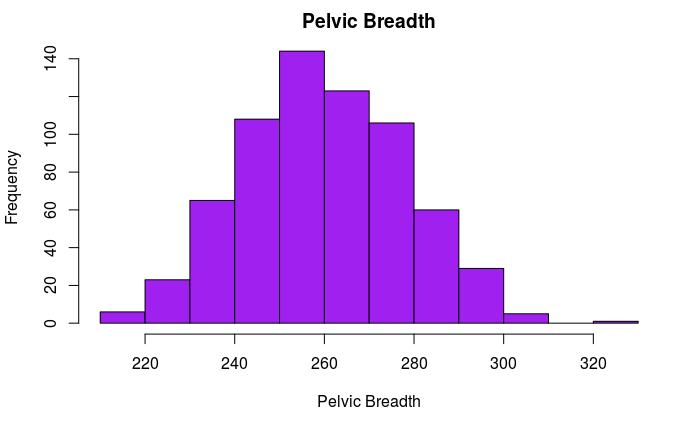

`r`r hist(DelPrete.orig$APOutlet, xlab = Outlet, main = Outlet, col = green)

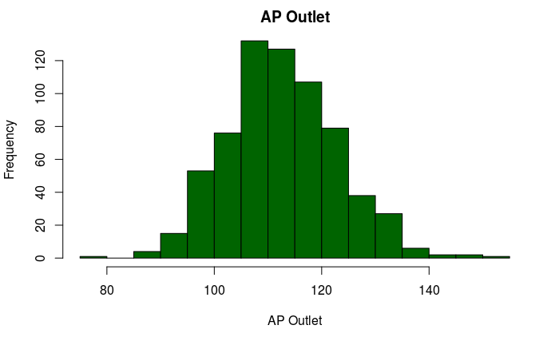

## ANCOVA

### AP INLET

`r`r cor.test(DelPrete.orig$APInlet, DelPrete.orig$Femur.Head.Adj)

```
    Pearson's product-moment correlation

data:  x and y
t = -5.441, df = 668, p-value = 7.443e-08
alternative hypothesis: true correlation is not equal to 0
95 percent confidence interval:
 -0.2774202 -0.1323242
sample estimates:
       cor
-0.2060042
```

`r`r contrasts(DelPrete.orig$LocationR)<-cbind(c(-5,1,1,1,1,1), c(0,-4,1,1,1,1),c(0,0,-3,1,1,1), c(0,0,0,-2,1,1), c(0,0,0,0,-1,1)) model.APInlet<-aov(APInlet ~ Gender*LocationR + Femur.Head.Adj, data = DelPrete.orig) Anova(model.APInlet, type=)

```
Anova Table (Type III tests)

Response: APInlet
                 Sum Sq  Df  F value    Pr(>F)
(Intercept)       66549   1 761.1567 < 2.2e-16 ***
Gender            12233   1 139.9175 < 2.2e-16 ***
LocationR          2305   5   5.2721 9.313e-05 ***
Femur.Head.Adj     1829   1  20.9183 5.729e-06 ***
Gender:LocationR    730   5   1.6689    0.1399
Residuals         57443 657
---
Signif. codes:  0 ‘***’ 0.001 ‘**’ 0.01 ‘*’ 0.05 ‘.’ 0.1 ‘ ’ 1
```

`r`r summary.lm(model.APInlet)

```
Call:
aov(formula = APInlet ~ Gender * LocationR + Femur.Head.Adj,
    data = DelPrete.orig)

Residuals:
    Min      1Q  Median      3Q     Max
-28.588  -5.557   0.760   5.586  32.138

Coefficients:
                     Estimate Std. Error t value Pr(>|t|)
(Intercept)         97.191561   3.522829  27.589  < 2e-16 ***
GenderM            -13.675862   1.156162 -11.829  < 2e-16 ***
LocationR1           0.250565   0.214098   1.170  0.24229
LocationR2          -0.306317   0.276798  -1.107  0.26885
LocationR3          -1.076208   0.365159  -2.947  0.00332 **
LocationR4           1.853132   0.604110   3.068  0.00225 **
LocationR5           2.428095   0.918347   2.644  0.00839 **
Femur.Head.Adj       0.025305   0.005533   4.574 5.73e-06 ***
GenderM:LocationR1  -0.346249   0.288130  -1.202  0.22991
GenderM:LocationR2   0.681046   0.392058   1.737  0.08284 .
GenderM:LocationR3   0.789831   0.516640   1.529  0.12680
GenderM:LocationR4  -1.191133   0.875983  -1.360  0.17437
GenderM:LocationR5  -0.423161   1.296711  -0.326  0.74428
---
Signif. codes:  0 ‘***’ 0.001 ‘**’ 0.01 ‘*’ 0.05 ‘.’ 0.1 ‘ ’ 1

Residual standard error: 9.35 on 657 degrees of freedom
Multiple R-squared:  0.2772,    Adjusted R-squared:  0.264
F-statistic:    21 on 12 and 657 DF,  p-value: < 2.2e-16
```

`r`r postHocs<-glht(model.APInlet, linfct = mcp(LocationR = ))

```
covariate interactions found -- default contrast might be inappropriate
```

`r`r summary(postHocs)

```
     Simultaneous Tests for General Linear Hypotheses

Multiple Comparisons of Means: Tukey Contrasts


Fit: aov(formula = APInlet ~ Gender * LocationR + Femur.Head.Adj,
    data = DelPrete.orig)

Linear Hypotheses:
               Estimate Std. Error t value Pr(>|t|)
HTB - CW == 0   2.72866    1.65378   1.650  0.56378
HTW - CW == 0   4.42570    1.66035   2.666  0.08309 .
SW - CW == 0   -3.58540    1.92530  -1.862  0.42471
TB - CW == 0   -0.45410    1.73076  -0.262  0.99983
TW - CW == 0    4.40209    1.75091   2.514  0.12056
HTW - HTB == 0  1.69704    1.71439   0.990  0.92061
SW - HTB == 0  -6.31406    1.97126  -3.203  0.01771 *
TB - HTB == 0  -3.18276    1.77308  -1.795  0.46789
TW - HTB == 0   1.67343    1.78030   0.940  0.93552
SW - HTW == 0  -8.01110    1.97753  -4.051  < 0.001 ***
TB - HTW == 0  -4.87980    1.78032  -2.741  0.06822 .
TW - HTW == 0  -0.02361    1.78791  -0.013  1.00000
TB - SW == 0    3.13130    2.02859   1.544  0.63443
TW - SW == 0    7.98749    2.03486   3.925  0.00139 **
TW - TB == 0    4.85619    1.83669   2.644  0.08774 .
---
Signif. codes:  0 ‘***’ 0.001 ‘**’ 0.01 ‘*’ 0.05 ‘.’ 0.1 ‘ ’ 1
(Adjusted p values reported -- single-step method)
```

`r`r confint(postHocs)

```
     Simultaneous Confidence Intervals

Multiple Comparisons of Means: Tukey Contrasts


Fit: aov(formula = APInlet ~ Gender * LocationR + Femur.Head.Adj,
    data = DelPrete.orig)

Quantile = 2.8555
95% family-wise confidence level


Linear Hypotheses:
               Estimate  lwr       upr
HTB - CW == 0    2.72866  -1.99368   7.45100
HTW - CW == 0    4.42570  -0.31540   9.16679
SW - CW == 0    -3.58540  -9.08306   1.91226
TB - CW == 0    -0.45410  -5.39627   4.48807
TW - CW == 0     4.40209  -0.59762   9.40180
HTW - HTB == 0   1.69704  -3.19838   6.59246
SW - HTB == 0   -6.31406 -11.94296  -0.68516
TB - HTB == 0   -3.18276  -8.24576   1.88024
TW - HTB == 0    1.67343  -3.41018   6.75704
SW - HTW == 0   -8.01110 -13.65790  -2.36430
TB - HTW == 0   -4.87980  -9.96349   0.20389
TW - HTW == 0   -0.02361  -5.12896   5.08175
TB - SW == 0     3.13130  -2.66130   8.92390
TW - SW == 0     7.98749   2.17698  13.79800
TW - TB == 0     4.85619  -0.38847  10.10085
```

### AP OUTLET

`r`r cor.test(DelPrete.orig$APOutlet, DelPrete.orig$Femur.Head.Adj)

```
    Pearson's product-moment correlation

data:  x and y
t = -4.1115, df = 668, p-value = 4.42e-05
alternative hypothesis: true correlation is not equal to 0
95 percent confidence interval:
 -0.23011158 -0.08234022
sample estimates:
       cor
-0.1571051
```

`r`r contrasts(DelPrete.orig$LocationR)<-cbind(c(-5,1,1,1,1,1), c(0,-4,1,1,1,1),c(0,0,-3,1,1,1), c(0,0,0,-2,1,1), c(0,0,0,0,-1,1)) model.APOutlet<-aov(APOutlet ~ Gender*LocationR + Femur.Head.Adj, data = DelPrete.orig) Anova(model.APOutlet, type=)

```
Anova Table (Type III tests)

Response: APOutlet
                 Sum Sq  Df  F value    Pr(>F)
(Intercept)       68171   1 954.5558 < 2.2e-16 ***
Gender            11899   1 166.6177 < 2.2e-16 ***
LocationR          5124   5  14.3496 2.371e-13 ***
Femur.Head.Adj     2550   1  35.7076 3.759e-09 ***
Gender:LocationR    385   5   1.0794    0.3705
Residuals         46921 657
---
Signif. codes:  0 ‘***’ 0.001 ‘**’ 0.01 ‘*’ 0.05 ‘.’ 0.1 ‘ ’ 1
```

`r`r summary.lm(model.APOutlet)

```
Call:
aov(formula = APOutlet ~ Gender * LocationR + Femur.Head.Adj,
    data = DelPrete.orig)

Residuals:
     Min       1Q   Median       3Q      Max
-26.2902  -5.7944   0.1897   5.1188  25.9432

Coefficients:
                    Estimate Std. Error t value Pr(>|t|)
(Intercept)         98.36876    3.18388  30.896  < 2e-16 ***
GenderM            -13.48790    1.04492 -12.908  < 2e-16 ***
LocationR1           0.66692    0.19350   3.447 0.000604 ***
LocationR2          -1.15061    0.25017  -4.599 5.09e-06 ***
LocationR3           0.49009    0.33003   1.485 0.138024
LocationR4           0.58593    0.54599   1.073 0.283594
LocationR5          -4.77460    0.82999  -5.753 1.35e-08 ***
Femur.Head.Adj       0.02988    0.00500   5.976 3.76e-09 ***
GenderM:LocationR1  -0.37290    0.26041  -1.432 0.152624
GenderM:LocationR2   0.17193    0.35434   0.485 0.627677
GenderM:LocationR3  -0.28337    0.46693  -0.607 0.544134
GenderM:LocationR4   0.33072    0.79170   0.418 0.676282
GenderM:LocationR5   1.90136    1.17195   1.622 0.105199
---
Signif. codes:  0 ‘***’ 0.001 ‘**’ 0.01 ‘*’ 0.05 ‘.’ 0.1 ‘ ’ 1

Residual standard error: 8.451 on 657 degrees of freedom
Multiple R-squared:  0.3355,    Adjusted R-squared:  0.3233
F-statistic: 27.64 on 12 and 657 DF,  p-value: < 2.2e-16
```

`r`r postHocs<-glht(model.APOutlet, linfct = mcp(LocationR = ))

```
covariate interactions found -- default contrast might be inappropriate
```

`r`r summary(postHocs)

```
     Simultaneous Tests for General Linear Hypotheses

Multiple Comparisons of Means: Tukey Contrasts


Fit: aov(formula = APOutlet ~ Gender * LocationR + Femur.Head.Adj,
    data = DelPrete.orig)

Linear Hypotheses:
               Estimate Std. Error t value Pr(>|t|)
HTB - CW == 0   8.60398    1.49466   5.756  < 0.001 ***
HTW - CW == 0   1.38068    1.50059   0.920  0.94093
SW - CW == 0    2.16917    1.74005   1.247  0.81247
TB - CW == 0    8.70156    1.56424   5.563  < 0.001 ***
TW - CW == 0   -0.84765    1.58245  -0.536  0.99466
HTW - HTB == 0 -7.22330    1.54944  -4.662  < 0.001 ***
SW - HTB == 0  -6.43481    1.78159  -3.612  0.00438 **
TB - HTB == 0   0.09758    1.60248   0.061  1.00000
TW - HTB == 0  -9.45162    1.60900  -5.874  < 0.001 ***
SW - HTW == 0   0.78849    1.78726   0.441  0.99787
TB - HTW == 0   7.32088    1.60903   4.550  < 0.001 ***
TW - HTW == 0  -2.22833    1.61589  -1.379  0.73831
TB - SW == 0    6.53239    1.83341   3.563  0.00518 **
TW - SW == 0   -3.01681    1.83907  -1.640  0.57025
TW - TB == 0   -9.54921    1.65998  -5.753  < 0.001 ***
---
Signif. codes:  0 ‘***’ 0.001 ‘**’ 0.01 ‘*’ 0.05 ‘.’ 0.1 ‘ ’ 1
(Adjusted p values reported -- single-step method)
```

`r`r confint(postHocs)

```
     Simultaneous Confidence Intervals

Multiple Comparisons of Means: Tukey Contrasts


Fit: aov(formula = APOutlet ~ Gender * LocationR + Femur.Head.Adj,
    data = DelPrete.orig)

Quantile = 2.8555
95% family-wise confidence level


Linear Hypotheses:
               Estimate  lwr       upr
HTB - CW == 0    8.60398   4.33602  12.87193
HTW - CW == 0    1.38068  -2.90423   5.66559
SW - CW == 0     2.16917  -2.79951   7.13784
TB - CW == 0     8.70156   4.23492  13.16820
TW - CW == 0    -0.84765  -5.36629   3.67099
HTW - HTB == 0  -7.22330 -11.64769  -2.79891
SW - HTB == 0   -6.43481 -11.52210  -1.34752
TB - HTB == 0    0.09758  -4.47826   4.67343
TW - HTB == 0   -9.45162 -14.04609  -4.85716
SW - HTW == 0    0.78849  -4.31498   5.89196
TB - HTW == 0    7.32088   2.72634  11.91542
TW - HTW == 0   -2.22833  -6.84245   2.38580
TB - SW == 0     6.53239   1.29715  11.76763
TW - SW == 0    -3.01681  -8.26824   2.23461
TW - TB == 0    -9.54921 -14.28923  -4.80919
```

### Bispinous

`r`r cor.test(DelPrete.orig$Bispinous, DelPrete.orig$Femur.Head.Adj)

```
    Pearson's product-moment correlation

data:  x and y
t = -12.713, df = 668, p-value < 2.2e-16
alternative hypothesis: true correlation is not equal to 0
95 percent confidence interval:
 -0.5003791 -0.3782634
sample estimates:
       cor
-0.4413624
```

`r`r contrasts(DelPrete.orig$LocationR)<-cbind(c(-5,1,1,1,1,1), c(0,-4,1,1,1,1),c(0,0,-3,1,1,1), c(0,0,0,-2,1,1), c(0,0,0,0,-1,1)) model.Bispinous<-aov(Bispinous ~ Gender*LocationR + Femur.Head.Adj, data = DelPrete.orig) Anova(model.Bispinous, type=)

```
Anova Table (Type III tests)

Response: Bispinous
                 Sum Sq  Df  F value    Pr(>F)
(Intercept)       55128   1 853.3258 < 2.2e-16 ***
Gender            28253   1 437.3355 < 2.2e-16 ***
LocationR          1494   5   4.6261 0.0003712 ***
Femur.Head.Adj     1735   1  26.8487 2.931e-07 ***
Gender:LocationR    709   5   2.1936 0.0533523 .
Residuals         42444 657
---
Signif. codes:  0 ‘***’ 0.001 ‘**’ 0.01 ‘*’ 0.05 ‘.’ 0.1 ‘ ’ 1
```

`r`r summary.lm(model.Bispinous)

```
Call:
aov(formula = Bispinous ~ Gender * LocationR + Femur.Head.Adj,
    data = DelPrete.orig)

Residuals:
     Min       1Q   Median       3Q      Max
-23.5880  -5.3698  -0.6884   5.0136  26.1161

Coefficients:
                     Estimate Std. Error t value Pr(>|t|)
(Intercept)         88.459062   3.028202  29.212  < 2e-16 ***
GenderM            -20.783538   0.993830 -20.913  < 2e-16 ***
LocationR1           0.344138   0.184038   1.870   0.0619 .
LocationR2           0.451596   0.237934   1.898   0.0581 .
LocationR3           0.046052   0.313889   0.147   0.8834
LocationR4          -2.037388   0.519290  -3.923 9.65e-05 ***
LocationR5           1.227931   0.789406   1.556   0.1203
Femur.Head.Adj       0.024643   0.004756   5.182 2.93e-07 ***
GenderM:LocationR1  -0.751728   0.247675  -3.035   0.0025 **
GenderM:LocationR2  -0.249822   0.337011  -0.741   0.4588
GenderM:LocationR3  -0.491309   0.444100  -1.106   0.2690
GenderM:LocationR4   0.123837   0.752990   0.164   0.8694
GenderM:LocationR5  -0.814305   1.114645  -0.731   0.4653
---
Signif. codes:  0 ‘***’ 0.001 ‘**’ 0.01 ‘*’ 0.05 ‘.’ 0.1 ‘ ’ 1

Residual standard error: 8.038 on 657 degrees of freedom
Multiple R-squared:  0.5402,    Adjusted R-squared:  0.5318
F-statistic: 64.32 on 12 and 657 DF,  p-value: < 2.2e-16
```

`r`r postHocs<-glht(model.Bispinous, linfct = mcp(LocationR = ))

```
covariate interactions found -- default contrast might be inappropriate
```

`r`r summary(postHocs)

```
     Simultaneous Tests for General Linear Hypotheses

Multiple Comparisons of Means: Tukey Contrasts


Fit: aov(formula = Bispinous ~ Gender * LocationR + Femur.Head.Adj,
    data = DelPrete.orig)

Linear Hypotheses:
               Estimate Std. Error t value Pr(>|t|)
HTB - CW == 0    0.2584     1.4216   0.182  0.99997
HTW - CW == 0    2.3783     1.4272   1.666  0.55289
SW - CW == 0     6.6373     1.6550   4.010  < 0.001 ***
TB - CW == 0    -0.7028     1.4878  -0.472  0.99705
TW - CW == 0     1.7530     1.5051   1.165  0.85251
HTW - HTB == 0   2.1198     1.4737   1.438  0.70195
SW - HTB == 0    6.3788     1.6945   3.764  0.00255 **
TB - HTB == 0   -0.9613     1.5241  -0.631  0.98862
TW - HTB == 0    1.4946     1.5303   0.977  0.92475
SW - HTW == 0    4.2590     1.6999   2.505  0.12313
TB - HTW == 0   -3.0811     1.5304  -2.013  0.33402
TW - HTW == 0   -0.6253     1.5369  -0.407  0.99856
TB - SW == 0    -7.3401     1.7438  -4.209  < 0.001 ***
TW - SW == 0    -4.8842     1.7492  -2.792  0.05953 .
TW - TB == 0     2.4559     1.5788   1.556  0.62656
---
Signif. codes:  0 ‘***’ 0.001 ‘**’ 0.01 ‘*’ 0.05 ‘.’ 0.1 ‘ ’ 1
(Adjusted p values reported -- single-step method)
```

`r`r confint(postHocs)

```
     Simultaneous Confidence Intervals

Multiple Comparisons of Means: Tukey Contrasts


Fit: aov(formula = Bispinous ~ Gender * LocationR + Femur.Head.Adj,
    data = DelPrete.orig)

Quantile = 2.8549
95% family-wise confidence level


Linear Hypotheses:
               Estimate lwr      upr
HTB - CW == 0    0.2584  -3.8000   4.3169
HTW - CW == 0    2.3783  -1.6963   6.4528
SW - CW == 0     6.6373   1.9125  11.3620
TB - CW == 0    -0.7028  -4.9502   3.5445
TW - CW == 0     1.7530  -2.5438   6.0498
HTW - HTB == 0   2.1198  -2.0874   6.3270
SW - HTB == 0    6.3788   1.5412  11.2164
TB - HTB == 0   -0.9613  -5.3125   3.3899
TW - HTB == 0    1.4946  -2.8744   5.8635
SW - HTW == 0    4.2590  -0.5940   9.1119
TB - HTW == 0   -3.0811  -7.4501   1.2879
TW - HTW == 0   -0.6253  -5.0129   3.7624
TB - SW == 0    -7.3401 -12.3183  -2.3618
TW - SW == 0    -4.8842  -9.8779   0.1094
TW - TB == 0     2.4559  -2.0515   6.9632
```

### TD OUTLET

`r`r cor.test(DelPrete.orig$TDOutlet, DelPrete.orig$Femur.Head.Adj)

```
    Pearson's product-moment correlation

data:  x and y
t = -10.558, df = 668, p-value < 2.2e-16
alternative hypothesis: true correlation is not equal to 0
95 percent confidence interval:
 -0.4412807 -0.3113502
sample estimates:
       cor
-0.3781764
```

`r`r contrasts(DelPrete.orig$LocationR)<-cbind(c(-5,1,1,1,1,1), c(0,-4,1,1,1,1),c(0,0,-3,1,1,1), c(0,0,0,-2,1,1), c(0,0,0,0,-1,1)) model.TDOutlet<-aov(TDOutlet ~ Gender*LocationR + Femur.Head.Adj, data = DelPrete.orig) Anova(model.TDOutlet, type=)

```
Anova Table (Type III tests)

Response: TDOutlet
                 Sum Sq  Df  F value    Pr(>F)
(Intercept)       78922   1 754.4357 < 2.2e-16 ***
Gender            26823   1 256.4031 < 2.2e-16 ***
LocationR          4930   5   9.4263 1.085e-08 ***
Femur.Head.Adj     1250   1  11.9474 0.0005825 ***
Gender:LocationR    878   5   1.6787 0.1375191
Residuals         68730 657
---
Signif. codes:  0 ‘***’ 0.001 ‘**’ 0.01 ‘*’ 0.05 ‘.’ 0.1 ‘ ’ 1
```

`r`r summary.lm(model.TDOutlet)

```
Call:
aov(formula = TDOutlet ~ Gender * LocationR + Femur.Head.Adj,
    data = DelPrete.orig)

Residuals:
    Min      1Q  Median      3Q     Max
-28.435  -6.186  -0.166   6.755  35.149

Coefficients:
                     Estimate Std. Error t value Pr(>|t|)
(Intercept)        105.841777   3.853417  27.467  < 2e-16 ***
GenderM            -20.250458   1.264658 -16.013  < 2e-16 ***
LocationR1           0.526662   0.234190   2.249 0.024851 *
LocationR2           1.513133   0.302774   4.998 7.45e-07 ***
LocationR3           0.461876   0.399426   1.156 0.247959
LocationR4          -2.732167   0.660801  -4.135 4.02e-05 ***
LocationR5           2.096672   1.004527   2.087 0.037253 *
Femur.Head.Adj       0.020918   0.006052   3.457 0.000582 ***
GenderM:LocationR1  -0.871046   0.315169  -2.764 0.005874 **
GenderM:LocationR2  -0.147049   0.428850  -0.343 0.731790
GenderM:LocationR3  -0.301074   0.565122  -0.533 0.594380
GenderM:LocationR4   0.806740   0.958187   0.842 0.400126
GenderM:LocationR5   0.679978   1.418397   0.479 0.631814
---
Signif. codes:  0 ‘***’ 0.001 ‘**’ 0.01 ‘*’ 0.05 ‘.’ 0.1 ‘ ’ 1

Residual standard error: 10.23 on 657 degrees of freedom
Multiple R-squared:  0.449, Adjusted R-squared:  0.439
F-statistic: 44.62 on 12 and 657 DF,  p-value: < 2.2e-16
```

`r`r postHocs<-glht(model.TDOutlet, linfct = mcp(LocationR = ))

```
covariate interactions found -- default contrast might be inappropriate
```

`r`r summary(postHocs)

```
     Simultaneous Tests for General Linear Hypotheses

Multiple Comparisons of Means: Tukey Contrasts


Fit: aov(formula = TDOutlet ~ Gender * LocationR + Femur.Head.Adj,
    data = DelPrete.orig)

Linear Hypotheses:
               Estimate Std. Error t value Pr(>|t|)
HTB - CW == 0   -2.8926     1.8090  -1.599  0.59774
HTW - CW == 0    3.2875     1.8162   1.810  0.45800
SW - CW == 0    10.5993     2.1060   5.033  < 0.001 ***
TB - CW == 0     0.3061     1.8932   0.162  0.99998
TW - CW == 0     4.4995     1.9152   2.349  0.17492
HTW - HTB == 0   6.1800     1.8753   3.296  0.01312 *
SW - HTB == 0   13.4919     2.1562   6.257  < 0.001 ***
TB - HTB == 0    3.1987     1.9395   1.649  0.56428
TW - HTB == 0    7.3920     1.9474   3.796  0.00220 **
SW - HTW == 0    7.3118     2.1631   3.380  0.00978 **
TB - HTW == 0   -2.9813     1.9474  -1.531  0.64266
TW - HTW == 0    1.2120     1.9557   0.620  0.98950
TB - SW == 0   -10.2932     2.2190  -4.639  < 0.001 ***
TW - SW == 0    -6.0998     2.2258  -2.740  0.06833 .
TW - TB == 0     4.1933     2.0091   2.087  0.29362
---
Signif. codes:  0 ‘***’ 0.001 ‘**’ 0.01 ‘*’ 0.05 ‘.’ 0.1 ‘ ’ 1
(Adjusted p values reported -- single-step method)
```

`r`r confint(postHocs)

```
     Simultaneous Confidence Intervals

Multiple Comparisons of Means: Tukey Contrasts


Fit: aov(formula = TDOutlet ~ Gender * LocationR + Femur.Head.Adj,
    data = DelPrete.orig)

Quantile = 2.8558
95% family-wise confidence level


Linear Hypotheses:
               Estimate lwr      upr
HTB - CW == 0   -2.8926  -8.0586   2.2735
HTW - CW == 0    3.2875  -1.8991   8.4741
SW - CW == 0    10.5993   4.5851  16.6136
TB - CW == 0     0.3061  -5.1004   5.7127
TW - CW == 0     4.4995  -0.9700   9.9690
HTW - HTB == 0   6.1800   0.8246  11.5355
SW - HTB == 0   13.4919   7.3340  19.6497
TB - HTB == 0    3.1987  -2.3401   8.7375
TW - HTB == 0    7.3920   1.8307  12.9533
SW - HTW == 0    7.3118   1.1344  13.4892
TB - HTW == 0   -2.9813  -8.5427   2.5801
TW - HTW == 0    1.2120  -4.3731   6.7971
TB - SW == 0   -10.2932 -16.6301  -3.9563
TW - SW == 0    -6.0998 -12.4563   0.2567
TW - TB == 0     4.1933  -1.5441   9.9308
```

### PELVIC BREADTH

`r`r cor.test(DelPrete.orig$PelvicBreadth, DelPrete.orig$Femur.Head.Adj)

```
    Pearson's product-moment correlation

data:  x and y
t = 9.1138, df = 668, p-value < 2.2e-16
alternative hypothesis: true correlation is not equal to 0
95 percent confidence interval:
 0.2634453 0.3982668
sample estimates:
      cor
0.3325541
```

`r`r contrasts(DelPrete.orig$LocationR)<-cbind(c(-5,1,1,1,1,1), c(0,-4,1,1,1,1),c(0,0,-3,1,1,1), c(0,0,0,-2,1,1), c(0,0,0,0,-1,1)) model.PelvicBreadth<-aov(PelvicBreadth ~ Gender*LocationR + Femur.Head.Adj, data = DelPrete.orig) Anova(model.PelvicBreadth, type=)

```
Anova Table (Type III tests)

Response: PelvicBreadth
                 Sum Sq  Df   F value    Pr(>F)
(Intercept)      265402   1 1373.5383 < 2.2e-16 ***
Gender            11252   1   58.2347  8.21e-14 ***
LocationR         24124   5   24.9701 < 2.2e-16 ***
Femur.Head.Adj    30404   1  157.3513 < 2.2e-16 ***
Gender:LocationR   3485   5    3.6071  0.003163 **
Residuals        126949 657
---
Signif. codes:  0 ‘***’ 0.001 ‘**’ 0.01 ‘*’ 0.05 ‘.’ 0.1 ‘ ’ 1
```

`r`r summary.lm(model.PelvicBreadth)

```
Call:
aov(formula = PelvicBreadth ~ Gender * LocationR + Femur.Head.Adj,
    data = DelPrete.orig)

Residuals:
    Min      1Q  Median      3Q     Max
-48.359  -9.678   0.079   9.188  37.301

Coefficients:
                     Estimate Std. Error t value Pr(>|t|)
(Intercept)        194.092767   5.237077  37.061  < 2e-16 ***
GenderM            -13.116173   1.718764  -7.631 8.21e-14 ***
LocationR1          -0.695391   0.318281  -2.185  0.02925 *
LocationR2           2.517985   0.411492   6.119 1.62e-09 ***
LocationR3          -1.583643   0.542850  -2.917  0.00365 **
LocationR4          -0.653719   0.898077  -0.728  0.46693
LocationR5          11.459111   1.365226   8.394 2.89e-16 ***
Femur.Head.Adj       0.103174   0.008225  12.544  < 2e-16 ***
GenderM:LocationR1  -0.077686   0.428337  -0.181  0.85614
GenderM:LocationR2   0.055733   0.582839   0.096  0.92385
GenderM:LocationR3  -2.306523   0.768042  -3.003  0.00277 **
GenderM:LocationR4  -2.889050   1.302247  -2.219  0.02686 *
GenderM:LocationR5  -2.928591   1.927705  -1.519  0.12919
---
Signif. codes:  0 ‘***’ 0.001 ‘**’ 0.01 ‘*’ 0.05 ‘.’ 0.1 ‘ ’ 1

Residual standard error: 13.9 on 657 degrees of freedom
Multiple R-squared:  0.4159,    Adjusted R-squared:  0.4052
F-statistic: 38.98 on 12 and 657 DF,  p-value: < 2.2e-16
```

`r`r postHocs<-glht(model.PelvicBreadth, linfct = mcp(LocationR = ))

```
covariate interactions found -- default contrast might be inappropriate
```

`r`r summary(postHocs)

```
     Simultaneous Tests for General Linear Hypotheses

Multiple Comparisons of Means: Tukey Contrasts


Fit: aov(formula = PelvicBreadth ~ Gender * LocationR + Femur.Head.Adj,
    data = DelPrete.orig)

Linear Hypotheses:
               Estimate Std. Error t value Pr(>|t|)
HTB - CW == 0   -14.244      2.459  -5.794   <0.001 ***
HTW - CW == 0     3.097      2.468   1.255   0.8083
SW - CW == 0     -1.931      2.862  -0.675   0.9846
TB - CW == 0    -15.351      2.573  -5.966   <0.001 ***
TW - CW == 0      7.567      2.603   2.907   0.0433 *
HTW - HTB == 0   17.341      2.549   6.804   <0.001 ***
SW - HTB == 0    12.314      2.930   4.202   <0.001 ***
TB - HTB == 0    -1.107      2.636  -0.420   0.9983
TW - HTB == 0    21.812      2.647   8.241   <0.001 ***
SW - HTW == 0    -5.027      2.940  -1.710   0.5237
TB - HTW == 0   -18.447      2.647  -6.970   <0.001 ***
TW - HTW == 0     4.471      2.658   1.682   0.5425
TB - SW == 0    -13.420      3.016  -4.450   <0.001 ***
TW - SW == 0      9.498      3.025   3.140   0.0216 *
TW - TB == 0     22.918      2.730   8.394   <0.001 ***
---
Signif. codes:  0 ‘***’ 0.001 ‘**’ 0.01 ‘*’ 0.05 ‘.’ 0.1 ‘ ’ 1
(Adjusted p values reported -- single-step method)
```

`r`r confint(postHocs)

```
     Simultaneous Confidence Intervals

Multiple Comparisons of Means: Tukey Contrasts


Fit: aov(formula = PelvicBreadth ~ Gender * LocationR + Femur.Head.Adj,
    data = DelPrete.orig)

Quantile = 2.8554
95% family-wise confidence level


Linear Hypotheses:
               Estimate lwr      upr
HTB - CW == 0  -14.2443 -21.2645  -7.2241
HTW - CW == 0    3.0966  -3.9515  10.1446
SW - CW == 0    -1.9306 -10.1033   6.2422
TB - CW == 0   -15.3508 -22.6978  -8.0039
TW - CW == 0     7.5674   0.1349  14.9999
HTW - HTB == 0  17.3409  10.0634  24.6183
SW - HTB == 0   12.3137   3.9459  20.6816
TB - HTB == 0   -1.1065  -8.6332   6.4201
TW - HTB == 0   21.8117  14.2544  29.3689
SW - HTW == 0   -5.0271 -13.4216   3.3673
TB - HTW == 0  -18.4474 -26.0048 -10.8900
TW - HTW == 0    4.4708  -3.1188  12.0604
TB - SW == 0   -13.4203 -22.0315  -4.8090
TW - SW == 0     9.4980   0.8601  18.1358
TW - TB == 0    22.9182  15.1216  30.7149
```

`r`r posthocinteractions<-lsmeans(model.PelvicBreadth, pairwise ~ Gender:LocationR, adjust = )

posthocinteractions$contrasts

```
 contrast      estimate   SE  df t.ratio p.value
 F,CW - M,CW     12.728 2.55 657   4.996 <.0001
 F,CW - F,HTB    14.244 2.46 657   5.794 <.0001
 F,CW - M,HTB    27.661 2.92 657   9.479 <.0001
 F,CW - F,HTW    -3.097 2.47 657  -1.255 0.9841
 F,CW - M,HTW     3.122 3.01 657   1.036 0.9968
 F,CW - F,SW      1.931 2.86 657   0.675 0.9999
 F,CW - M,SW     11.597 3.26 657   3.552 0.0208
 F,CW - F,TB     15.351 2.57 657   5.966 <.0001
 F,CW - M,TB     30.756 3.14 657   9.800 <.0001
 F,CW - F,TW     -7.567 2.60 657  -2.907 0.1407
 F,CW - M,TW     13.695 3.25 657   4.217 0.0017
 M,CW - F,HTB     1.517 2.51 657   0.603 1.0000
 M,CW - M,HTB    14.933 2.38 657   6.269 <.0001
 M,CW - F,HTW   -15.824 2.53 657  -6.261 <.0001
 M,CW - M,HTW    -9.606 2.42 657  -3.976 0.0044
 M,CW - F,SW    -10.797 2.91 657  -3.712 0.0119
 M,CW - M,SW     -1.131 2.89 657  -0.391 1.0000
 M,CW - F,TB      2.623 2.58 657   1.019 0.9973
 M,CW - M,TB     18.028 2.53 657   7.115 <.0001
 M,CW - F,TW    -20.295 2.53 657  -8.014 <.0001
 M,CW - M,TW      0.967 2.58 657   0.374 1.0000
 F,HTB - M,HTB   13.417 2.84 657   4.717 0.0002
 F,HTB - F,HTW  -17.341 2.55 657  -6.804 <.0001
 F,HTB - M,HTW  -11.122 2.92 657  -3.804 0.0085
 F,HTB - F,SW   -12.314 2.93 657  -4.202 0.0018
 F,HTB - M,SW    -2.647 3.22 657  -0.822 0.9996
 F,HTB - F,TB     1.107 2.64 657   0.420 1.0000
 F,HTB - M,TB    16.512 3.04 657   5.423 <.0001
 F,HTB - F,TW   -21.812 2.65 657  -8.241 <.0001
 F,HTB - M,TW    -0.549 3.14 657  -0.175 1.0000
 M,HTB - F,HTW  -30.758 2.86 657 -10.760 <.0001
 M,HTB - M,HTW  -24.539 2.54 657  -9.648 <.0001
 M,HTB - F,SW   -25.731 3.20 657  -8.043 <.0001
 M,HTB - M,SW   -16.064 3.05 657  -5.265 <.0001
 M,HTB - F,TB   -12.310 2.88 657  -4.268 0.0014
 M,HTB - M,TB     3.095 2.64 657   1.170 0.9910
 M,HTB - F,TW   -35.228 2.83 657 -12.469 <.0001
 M,HTB - M,TW   -13.966 2.67 657  -5.236 <.0001
 F,HTW - M,HTW    6.219 2.94 657   2.116 0.6113
```

[output cut: 14 more lines]

```
 F,SW - M,TB     28.825 3.38 657   8.533 <.0001
 F,SW - F,TW     -9.498 3.03 657  -3.140 0.0755
 F,SW - M,TW     11.764 3.46 657   3.397 0.0347
 M,SW - F,TB      3.754 3.26 657   1.150 0.9922
 M,SW - M,TB     19.159 3.16 657   6.066 <.0001
 M,SW - F,TW    -19.165 3.22 657  -5.946 <.0001
 M,SW - M,TW      2.098 3.19 657   0.658 1.0000
 F,TB - M,TB     15.405 3.07 657   5.012 <.0001
 F,TB - F,TW    -22.918 2.73 657  -8.394 <.0001
 F,TB - M,TW     -1.656 3.16 657  -0.524 1.0000
 M,TB - F,TW    -38.323 3.01 657 -12.750 <.0001
 M,TB - M,TW    -17.061 2.73 657  -6.245 <.0001
 F,TW - M,TW     21.262 3.09 657   6.890 <.0001

P value adjustment: tukey method for comparing a family of 12 estimates
```